# 16 - ANOSIM and SIMPER

Francisco E. Fonturbel

23/November/2022

## How to analyze species composition?

Dealing with biodiversity data is somewhat different than dealing with the usual stuff that we are used to. Some authors use standard approaches (e.g., ANOVA) to compare species composition among sites, but this is not correct as in this case the identity of the species matters, and traditional methods cannot consider them.

```r
library(vegan)

data<-read.table("data/16_bird_data.txt",
                     header=TRUE,
                     sep="\t", dec=".",
                     na.strings="NA")
attach(data)
head(data)
```

```
##   Sample    Habitat CACHUDITO CARPINTERITO CARPINTERO_NEGRO CHUCAO CHUNCHO
## 1  Point     Native         1            0                0     10       0
## 2  Point Plantation         0            0                0      8       0
## 3  Point  Secondary         0            0                0      7       0
## 4  Point  Secondary         0            0                0     10       0
## 5  Point Plantation         0            0                0      3       0
## 6  Point Plantation         0            0                0      3       0
##   CHURRIN COLIBRI COLILARGA COMESEBO COMETOCINO DIUCON FIOFIO HUETHUET JILGUERO
## 1       0      27         1        0         15      2      5        3        0
## 2       2      26         0        0          4      4     10        1        0
## 3       0      14         0        0          3      0      1        1        0
## 4       0      36         0        0          0      1     11        2        0
## 5       0      11         0        0          2      0      7        1        0
## 6       2      18         0        0          0      0      1        0        0
##   PITIO RAYADITO TIJERAL TORCAZA TORDO ZORZAL
## 1     1       17       1       0     0      0
## 2     0        7       0       0     0      0
## 3     0        3       0       0     0      0
## 4     0       12       0       7     2      3
## 5     0        2       0       1     0      0
## 6     0        4       0       1     3      0
```

We will use the data of [Fontúrbel et al. 2020](https://www.sciencedirect.com/science/article/pii/S1470160X20308013) to illustrate this. This dataset contains bird abundance data for camera trap and point count data, comparing four habitat conditions.

## Analysis of Similarities (ANOSIM)

When we have species presence/absence or relative abundance data with two or more groups and at least three replicates per group, we can use the Analysis of Similarities (ANOSIM) to test for species composition differences. ANOSIM is a non-parametric approach that uses a similarity metric (e.g., Jaccard or Bray-Curtis) to compare species similarity within and between groups (following the same logic than ANOVA). The resulting statistics (R) is not a proportional value as it is calculated upon rankings (and it should not be interpreted as a linear scale of difference). The significance of this test is estimated using permutations (P value is the number of times that the randomized R value is equal or greater than the real R value, divided by the number of permutations). ANOSIM is implemented in the `vegan` package.

```r
#Extract the columns with species data in a separate object
birds<-data[,3:22]

#Creating a distance matrix
birdist<-vegdist(birds)

#ANOSIM per habitat
forestbirds<-anosim(birdist, data$Habitat, permutations = 999, distance = "bray")
summary(forestbirds)
```

```
##
## Call:
## anosim(x = birdist, grouping = data$Habitat, permutations = 999,      distance = "bray")
## Dissimilarity: bray
##
## ANOSIM statistic R: 0.03497
##       Significance: 0.194
##
## Permutation: free
## Number of permutations: 999
##
## Upper quantiles of permutations (null model):
##    90%    95%  97.5%    99%
## 0.0544 0.0736 0.0909 0.1097
##
## Dissimilarity ranks between and within classes:
##              0%     25%    50%     75%  100%   N
## Between     1.0 164.375 318.75 474.250 630.0 486
## Logged     30.0 175.875 327.00 496.125 595.0  36
## Native      2.0  92.125 207.50 327.000 598.0  36
## Plantation 37.0 136.750 327.50 556.625 619.0  36
## Secondary  19.5 206.250 419.25 493.875 603.5  36
```

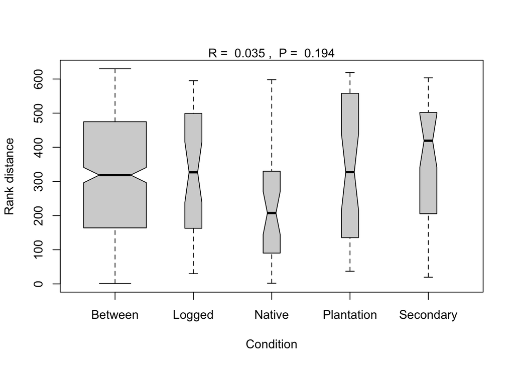

```r
plot(forestbirds, xlab="Condition", ylab="Rank distance")
```

So, there is no difference among habitat conditions. What about sampling approaches?

```r
sampbirds<-anosim(birdist, data$Sample, permutations = 999, distance = "bray")
summary(sampbirds)
```

```
##
## Call:
## anosim(x = birdist, grouping = data$Sample, permutations = 999,      distance = "bray")
## Dissimilarity: bray
##
## ANOSIM statistic R: 0.2712
##       Significance: 0.001
##
## Permutation: free
## Number of permutations: 999
##
## Upper quantiles of permutations (null model):
##    90%    95%  97.5%    99%
## 0.0502 0.0705 0.0917 0.1189
##
## Dissimilarity ranks between and within classes:
##         0%     25%    50%     75% 100%   N
## Between  2 192.750 347.50 496.250  629 432
## Camera1 17 178.875 312.75 449.250  630  66
## Camera2 29 221.000 383.50 488.625  627  66
## Point    1  19.875  58.50 162.500  337  66
```

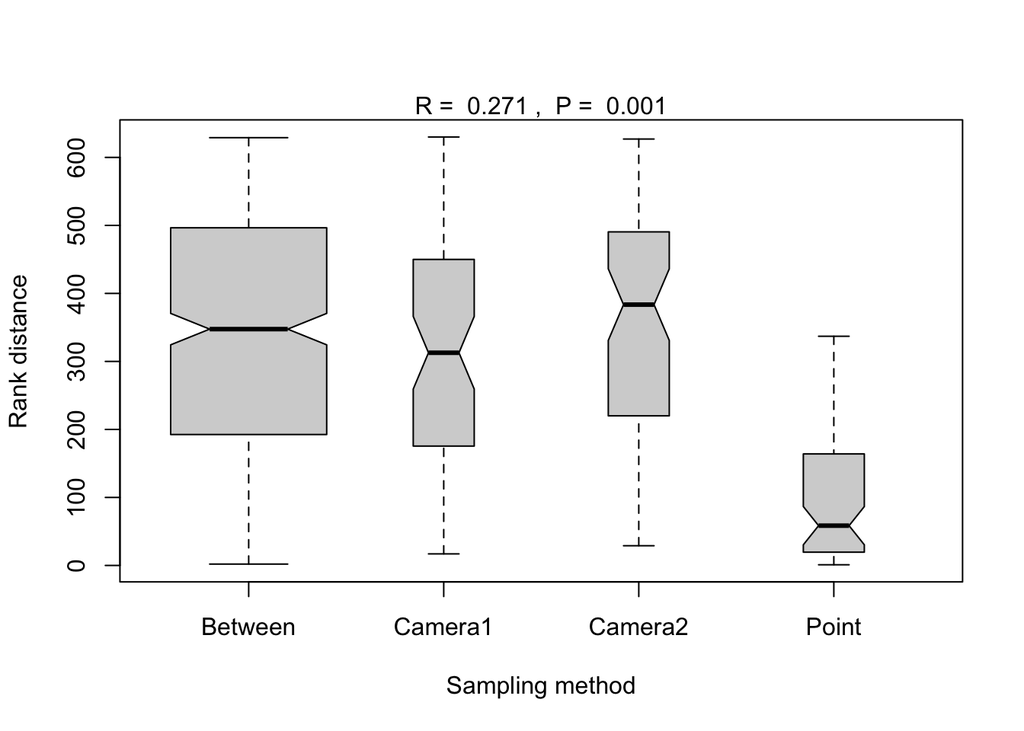

```r
plot(sampbirds, xlab="Sampling method", ylab="Rank distance")
```

In this case, we found a significant difference, in which point counts are different from camera traps.

## Which species explain the differences?

In the second case, we found a significant difference in the ANOSIM test. But, which species account for such differences? In this case, we can use the Similarity Percentages (SIMPER) test, also implemented in the `vegan` package.

```r
simbirds<-simper(birds, group = data$Sample, permutations = 999)
summary(simbirds, digits = "3")
```

```
##
## Contrast: Point_Camera1
##
##                   average      sd ratio     ava    avb cumsum     p
## COLIBRI          0.248414 0.11987 2.072 30.1667 7.6667  0.384 0.001 ***
## FIOFIO           0.077005 0.05382 1.431  7.9167 2.5833  0.503 0.045 *
## CHUCAO           0.074271 0.04397 1.689  8.0000 2.4167  0.617 0.250
## RAYADITO         0.052809 0.04120 1.282  6.7500 3.2500  0.699 0.998
## ZORZAL           0.044733 0.05373 0.833  2.1667 4.2500  0.768 0.977
## COMETOCINO       0.031288 0.03889 0.805  2.8333 0.5000  0.816 0.001 ***
## HUETHUET         0.020458 0.01848 1.107  1.4167 1.8333  0.848 0.982
## CHURRIN          0.016848 0.01430 1.178  1.5833 0.0833  0.874 0.001 ***
## COLILARGA        0.016059 0.01816 0.884  0.9167 1.2500  0.899 0.885
## TORCAZA          0.015512 0.02178 0.712  1.5833 0.0000  0.923 0.652
## TORDO            0.013090 0.01682 0.778  0.6667 0.7500  0.943 0.318
## DIUCON           0.007627 0.01339 0.570  0.7500 0.0000  0.955 0.001 ***
## COMESEBO         0.006070 0.00862 0.705  0.0000 0.5833  0.964 0.992
## JILGUERO         0.005427 0.00914 0.593  0.5000 0.1667  0.972 0.183
## PITIO            0.005243 0.00672 0.781  0.4167 0.2500  0.980 0.496
## CACHUDITO        0.004415 0.00663 0.666  0.5000 0.0000  0.987 0.001 ***
## CHUNCHO          0.003184 0.00656 0.486  0.2500 0.0833  0.992 0.905
## CARPINTERITO     0.002792 0.00554 0.504  0.2500 0.0833  0.996 0.735
## CARPINTERO_NEGRO 0.001539 0.00354 0.434  0.1667 0.0000  0.999 0.682
## TIJERAL          0.000779 0.00262 0.298  0.0833 0.0000  1.000 0.993
##
## Contrast: Point_Camera2
##
##                  average      sd ratio     ava    avb cumsum     p
## COLIBRI          0.22440 0.11527 1.947 30.1667 8.6667  0.348 0.003 **
## CHUCAO           0.08095 0.04587 1.765  8.0000 4.7500  0.474 0.035 *
## RAYADITO         0.06681 0.05096 1.311  6.7500 9.2500  0.577 0.844
## FIOFIO           0.06299 0.04873 1.293  7.9167 2.8333  0.675 0.613
## ZORZAL           0.04668 0.04489 1.040  2.1667 5.7500  0.747 0.939
## COMETOCINO       0.02874 0.03678 0.781  2.8333 0.1667  0.792 0.010 **
## HUETHUET         0.02590 0.03229 0.802  1.4167 2.4167  0.832 0.830
## TORCAZA          0.02263 0.03329 0.680  1.5833 1.2500  0.867 0.256
## CHURRIN          0.01634 0.01344 1.216  1.5833 0.4167  0.893 0.001 ***
## COLILARGA        0.01348 0.01502 0.898  0.9167 1.1667  0.913 0.969
## COMESEBO         0.01004 0.01443 0.695  0.0000 1.0833  0.929 0.817
## TORDO            0.00772 0.01490 0.518  0.6667 0.0833  0.941 0.928
```

[output cut: 21 more lines]

```
## TORDO            0.01399 0.02174 0.643 0.7500 0.0833  0.929 0.217
## CHUNCHO          0.00959 0.02050 0.468 0.0833 0.5000  0.944 0.068 .
## COMETOCINO       0.00889 0.01313 0.677 0.5000 0.1667  0.958 0.997
## TIJERAL          0.00726 0.01126 0.645 0.0000 0.5000  0.969 0.001 ***
## PITIO            0.00557 0.01028 0.542 0.2500 0.0833  0.978 0.350
## CARPINTERITO     0.00367 0.00936 0.392 0.0833 0.2500  0.984 0.481
## CHURRIN          0.00367 0.00906 0.405 0.0833 0.4167  0.990 1.000
## CARPINTERO_NEGRO 0.00356 0.01198 0.297 0.0000 0.3333  0.995 0.532
## JILGUERO         0.00306 0.00769 0.398 0.1667 0.0000  1.000 0.784
## CACHUDITO        0.00000 0.00000   NaN 0.0000 0.0000  1.000 1.000
## DIUCON           0.00000 0.00000   NaN 0.0000 0.0000  1.000 1.000
## ---
## Signif. codes:  0 '***' 0.001 '**' 0.01 '*' 0.05 '.' 0.1 ' ' 1
## Permutation: free
## Number of permutations: 999
```

## Final thoughts

ANOSIM and SIMPER are simple tests to test for species composition differences and provide an actual hypothesis test with a proper P value. This approach is more appropriate to analyze species composition data rather than other approaches, such as ANOVA, which may be giving unreliable results.

Licensing Creative Commons License

Licensed under a Creative Commons Attribution-ShareAlike 4.0 International License.  
2022 - Francisco E. Fontúrbel